# act_report

## Report: act_report

This contains a written report that communicates the insights and displays the visualizations produced from the wrangled data.

## Analyzing and Visualizing Data

### Insights:

1. What breed and dog stage have the highest counts.
2. Which dog stage has the highest retweet and like
3. Does dog rating determine retweet_count and favourite count?
4. Which source of tweet has the highest count

#### Question1: What breed and dog stage have the highest counts.

#### Insight 1:

> The golden_retriever is the most prominent dog breed and the pupper dog stage has the highest count.

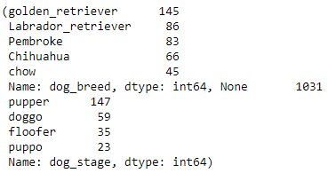

#### Visualization 1

[figure not shown]

#### Question 2: Which dog stage has the highest retweet and like

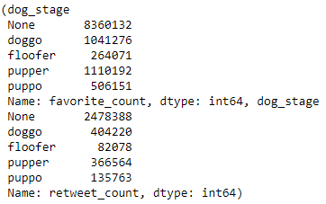

#### Insight 2:

> The pupper dog stage has the higest likes(favorite count) and the doggo dog stage has the highest retweet count.

#### Question 3: Does dog rating determine retweet_count and favourite count?

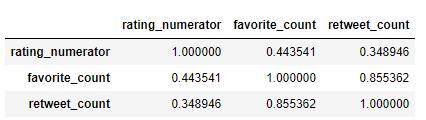

#### Insight 3:

> There is a relatively small positive correlation between rating and retweet_count & favourite count.

#### Visualization2:

Correlation Heatmap

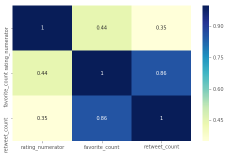

#### Question 4: Which source of tweet has the highest count.

#### Insight 4:

> Iphone users have the highest tweet count followed by Web Client

#### Visualization3:

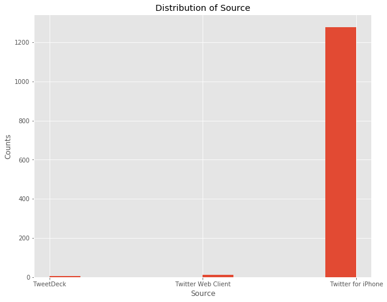

### Visualization

#### Distribution of the twitter archived master dataset.

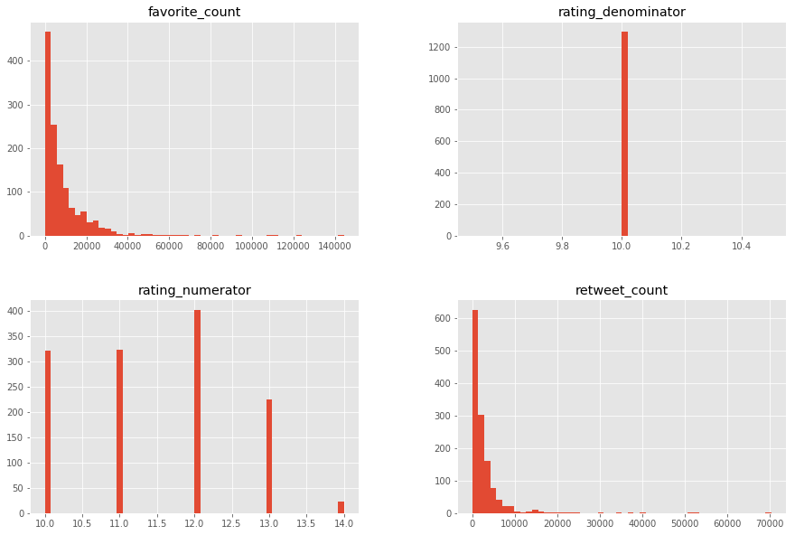

#### Visualization of the relationship between Retweet count and favourite count

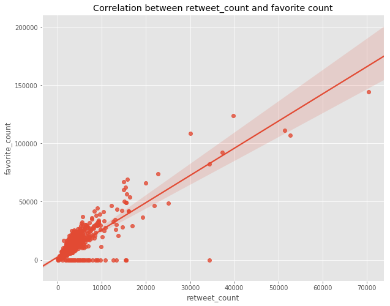

#### Visualization of the relationship between Retweet count and rating numerator

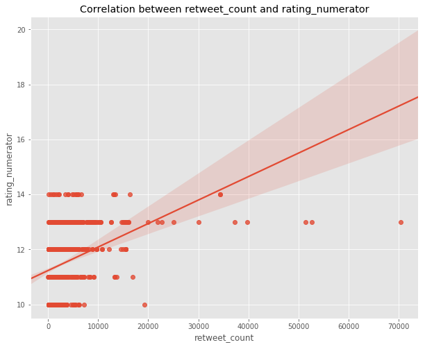

#### Visualization of the relationship between favorite count and rating numerator

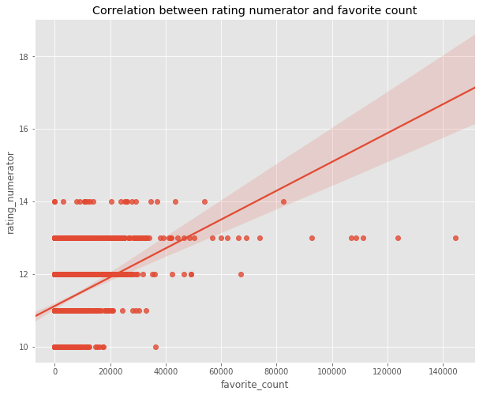

#### Insight:

- The distribution of Retweet count and favourite count is skewed to the right.
- Retweet count and favourite count are highly positively correlated.
- Retweet count and rating numerator are slightly positively correlated.
- Favorite count and rating numerator are slightly positively correlated.